# Investigate a "No-show appointments" Dataset

## Answer is : There is no relation between the absence and the atend with the scholar ship

### Q5)_ Does **SMS** Affect the Attendance?

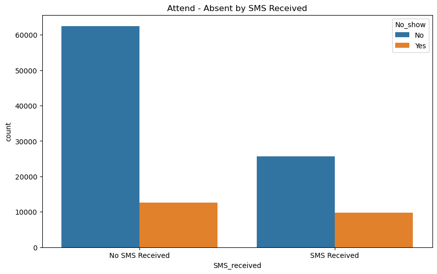

```python
# Call the function for 'SMS_received'
plot_attendance_status(column='SMS_received', x_labels=['No SMS Received', 'SMS Received'], title='Attend - Absent by SMS Received')
```

## Answer : We can see there is a relation ship the people how resived sms the no shown a bigger than the other one

### Q6)_ Does Handicap Affect the Attendance?

```
attend_counts = Handcap
0    86373
1     1676
2      146
3       10
4        2
Name: count, dtype: int64 and absent_counts = Handcap
0    21912
1      366
2       37
3        3
4        1
Name: count, dtype: int64
```

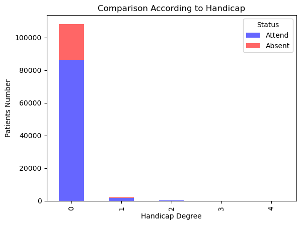

```python
# Count the occurrences of each handicap degree in the 'attend' group (patients who attended)
attend_counts = df[attend]['Handcap'].value_counts()
# Count the occurrences of each handicap degree in the 'absent' group (patients who were absent)
absent_counts = df[absent]['Handcap'].value_counts()
print(f'attend_counts = {attend_counts} and absent_counts = {absent_counts}')
# Combine the attend and absent counts into a single DataFrame
# Use fillna(0) to replace any missing values with 0, ensuring all handicap degrees are represented
handicap_data = pd.DataFrame({'Attend': attend_counts, 'Absent': absent_counts}).fillna(0)
# Create a new figure with the specified size
plt.figure(figsize=[14, 4])
# Plot the handicap data as a stacked bar plot
# 'kind="bar"' specifies a bar plot, 'stacked=True' stacks the bars for each category
# 'color=['blue', 'red']' sets the bar colors, 'alpha=0.6' sets the transparency of the bars
handicap_data.plot(kind='bar', stacked=True, color=['blue', 'red'], alpha=0.6)
# Set the title of the plot
plt.title('Comparison According to Handicap')
# Set the label for the x-axis
plt.xlabel('Handicap Degree')
# Set the label for the y-axis
plt.ylabel('Patients Number')
# Add a legend with the title 'Status' to differentiate between attend and absent bars
plt.legend(title='Status')
# Display the plot
plt.show()
```

```python
print(f'the ratio of the have no handicap and didnt came is {(108285-86373)/108285}')
```

```
the ratio of the have no handicap and didnt came is 0.20235489680011082
```

```python
print(f'the ratio of the have handicap and didnt came is {(2042-1676)/2042}')
```

```
the ratio of the have handicap and didnt came is 0.1792360430950049
```

## Answer : And we can see there is no relation between the handicap and the absence and the atended

### Q7)_ Does Age and Chronic Deseases (Diabetes, Hypertension) Affect the Attendence?

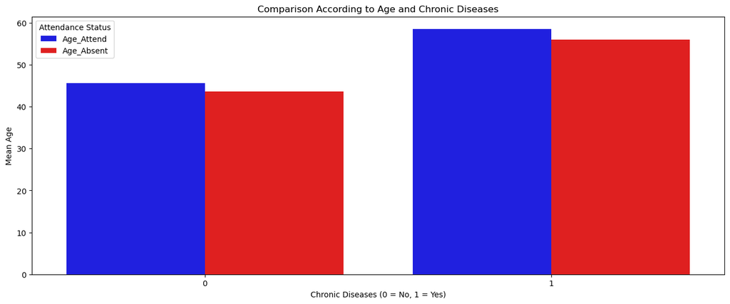

```python
# Calculate mean age for attendees grouped by Diabetes and Hypertension
attend_means = df[attend].groupby(['Diabetes', 'Hypertension']).Age.mean().reset_index()

# Calculate mean age for absentees grouped by Diabetes and Hypertension
absent_means = df[absent].groupby(['Diabetes', 'Hypertension']).Age.mean().reset_index()
# Merge the two DataFrames on Diabetes and Hypertension
mean_age_comparison = pd.merge(attend_means, absent_means, on=['Diabetes', 'Hypertension'], suffixes=('_Attend', '_Absent'))
# Melt the DataFrame for easier plotting with seaborn
mean_age_comparison_melted = mean_age_comparison.melt(id_vars=['Diabetes', 'Hypertension'],
                                                      value_vars=['Age_Attend', 'Age_Absent'],
                                                      var_name='Status',
                                                      value_name='Mean Age')
# Create a new figure with specified size
plt.figure(figsize=[16, 6])
# Create a bar plot using seaborn
sns.barplot(data=mean_age_comparison_melted, x='Diabetes', y='Mean Age', hue='Status',
            palette=['blue', 'red'], ci=None, dodge=True)
# Set the plot title
plt.title('Comparison According to Age and Chronic Diseases')
# Set the x-axis label
plt.xlabel('Chronic Diseases (0 = No, 1 = Yes)')
# Set the y-axis label
plt.ylabel('Mean Age')
# Add a legend with title
plt.legend(title='Attendance Status')
# Display the plot
plt.show()
```

### Answer : It Not effect the Chronic Deseases of the Attendance the same ratio for both

## Q8)_ Does **Nighbourhood and Age** Affect the Attendance?

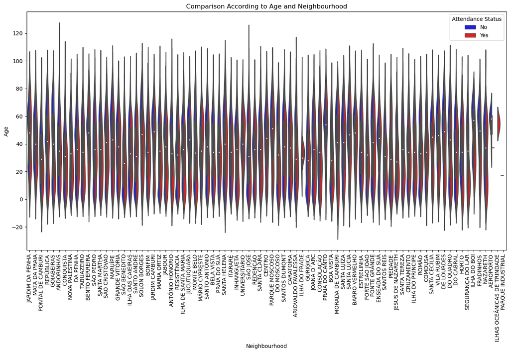

```python
# Create a new figure with specified size
plt.figure(figsize=[16, 8])
# Create a violin plot using seaborn
sns.violinplot(x='Neighbourhood', y='Age', hue='No_show', data=df, split=True, palette={'No': 'blue', 'Yes': 'red'})
# Set the plot title
plt.title('Comparison According to Age and Neighbourhood')
# Set the x-axis label
plt.xlabel('Neighbourhood')
# Set the y-axis label
plt.ylabel('Age')
# Rotate x-axis labels for better readability
plt.xticks(rotation=90)
# Add a legend with title and position
plt.legend(title='Attendance Status', loc='upper right')
# Display the plot
plt.show()
```

## Answer : The highest ages of those who attended are From **ANDORINHAS**

### Q9)_ Does **Neighbourhood and SMS** Affect the Attendance?

[figure not shown]

```python
# Calculate mean SMS received for attendees grouped by Neighbourhood
mean_sms_attend = df[df['No_show'] == 'No'].groupby('Neighbourhood')['SMS_received'].mean()
# Calculate mean SMS received for absentees grouped by Neighbourhood
mean_sms_absent = df[df['No_show'] == 'Yes'].groupby('Neighbourhood')['SMS_received'].mean()
# Combine the mean SMS data into a DataFrame and fill NaNs with 0
mean_sms_combined = pd.DataFrame({'Attend': mean_sms_attend, 'Absent': mean_sms_absent}).fillna(0).reset_index()
# Pivot the DataFrame for the heatmap
mean_sms_pivot = mean_sms_combined.pivot(index='Neighbourhood', columns='Attend', values='Absent')
# Create a new figure with specified size
plt.figure(figsize=[20, 10])
# Create a heatmap using seaborn
sns.heatmap(mean_sms_pivot, annot=True, cmap='coolwarm', fmt=".2f")
# Set the plot title
plt.title('Heatmap of Mean SMS Received by Neighbourhood and Attendance Status')
# Set the x-axis label
plt.xlabel('Attendance Status')
# Set the y-axis label
plt.ylabel('Neighbourhood')
# Display the plot
plt.show()
```

- I cant diside actully

## Conclusions

### The goal of this investigation was to identify the variables that affect Brazilian patients' attendance at doctor's appointments. The dataset contains many attributes for every patient, including the day of the appointment, the hospital's area, and the patient's enrollment status in the Brazilian assistance program Bolsa Família. The 'No-show' column, of particular note, shows 'Yes' if the patient missed their appointment and 'No' if they did.

**While we did not find definitive relationships between the variables studied and appointment attendance, these findings should be interpreted with caution. It is possible that other unexamined factors or more nuanced interactions between variables could play a role in influencing attendance. Additionally, limitations in the dataset or methodology may have impacted the results.**

**All things considered, this investigation provides preliminary insights into patient behavior that could inform future research and help improve the delivery of healthcare services in Brazil. Further studies with more comprehensive data and refined analytical approaches are needed to draw more conclusive findings.**